# Analysis of cell types most enriched for DEGs in several ASD patients.

# Mid-term Portfolio

### 생명공학부 2015140304 이동찬

Question : 다른 cell type과 비교했을 때, 여러 pateint에서 특이적으로 많은 DEG를 가지는 cell type들은 무엇이 있으며 해당 cell types’ DEG들은 ASD에 주요한 역할을 하는가?

주제 논문의 main topic이 single cell sequencing을 이용한 ASD에서의 cell type specific change에 대한 분석이기 때문에, 논문과 supplementary data, figure를 보며 가장 먼저 cell type 별 DEGs 수를 확인하였습니다.(Fig.2.I)

그 후, 논문에서 ASD의 clinical severity와 연관성을 가진다고 제시한 cell type들에 매우 적은 DEGs를 보이는 L5/6-CC가 포함된다는 것을 확인하였습니다.(Fig.4.B와 논문 본문)

또한, L5/6-CC의 5명 이상의 환자에서 공통적으로 나타나는 DEG의 비율이 매우 높음을 확인하였습니다.(Fig.S5.D) 이러한 data를 통해 다른 cell type에 비해 여러 pateint에서 특이적으로 많은 DEG를 가지는 cell type들의 DEGs가 ASD에 주요한 역할을 하는지 의문을 가지게 되었습니다.

이를 확인하기 위하여 가장 먼저 여러 pateint에서 특이적으로 많은 DEG를 가지는 cell types을 확인하고자 하였습니다. 특이적으로 많은 DEG를 가지는 cell types을 확인하기 위하여 각 cell type의 총 DEGs 수와 여러 환자에서 발견되는 DEGs 수로 point plot을 그린 후 outlier를 확인하였습니다.

먼저, Data S4의 4번 시트인 Individual_specific_DEGs 시트를 통해 5명 이상의 환자에서 나타나는 DEGs의 gene name과 cell type을 확인할 수 있었습니다. 그리고 Data S4의 1번 시트인 ASD_DEGs 시트에서 각 cell type별 total DEGs 수를 count하였습니다. 이후 Data S4의 1번 시트의 cell type 별 DEG를 여러 환자에서 발견되는 DEG list로 filtering한 뒤 count하여 cell type별로 여러 환자에서 공통적으로 나타나는 DEG 수를 확인하였습니다.

[output not shown]

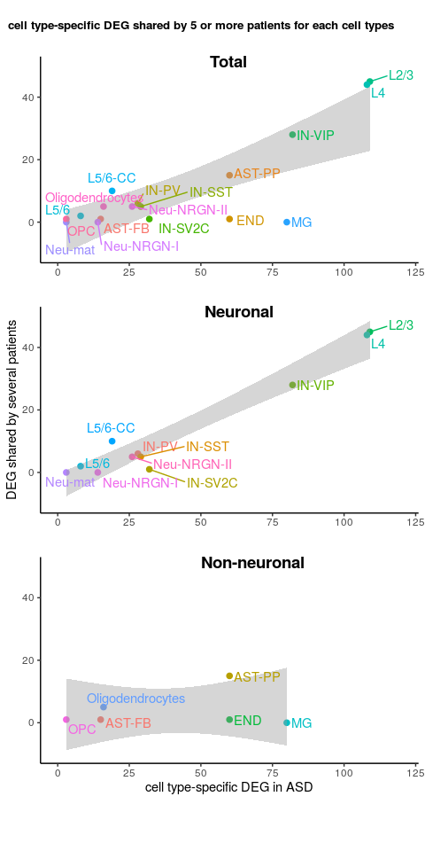

```r
plot_grid(ggdraw() +
            draw_label(
              "cell type-specific DEG shared by 5 or more patients for each cell types",
              size = 10,
              fontface = 'bold', x = 0, hjust = 0) +
            theme(plot.margin = margin(0, 0, 0, 7)),
          ggplot(df, aes(x= n, y= m_p, label = `Cell type`)) +
              geom_point(aes(color= `Cell type`), size =2) +
              geom_smooth(method =lm, colour = 0.5) +
              geom_text_repel(aes(color= `Cell type`),
                              nudge_x = 5, nudge_y = -0.02) +
              theme_classic() +
              theme(legend.position = "none") +
            coord_cartesian(xlim = c(0, 120), ylim = c(-10, 50)) +
              labs(x = "", y = ""),
          ggplot(df %>%
                   filter(neuron == "neuronal"),
                 aes(x= n, y= m_p, label = `Cell type`)) +
            geom_point(aes(color= `Cell type`), size =2) +
            geom_smooth(method =lm, colour = 0.5) +
            geom_text_repel(aes(color= `Cell type`), nudge_x = 5, nudge_y = -0.05) +
            theme_classic() +
            theme(legend.position = "none")  +
            coord_cartesian(xlim = c(0, 120), ylim = c(-10, 50))+
            labs(x = "", y = "DEG shared by several patients"),
          ggplot(df %>%
                   filter(neuron == "non-neuronal"),
                 aes(x= n, y= m_p, label = `Cell type`)) +
            geom_point(aes(color= `Cell type`), size =2) +
            geom_smooth(method =lm, colour = 0.5) +
            geom_text_repel(aes(color= `Cell type`), nudge_x = 5, nudge_y = -0.05) +
            theme_classic() +
            theme(legend.position = "none")  +
            coord_cartesian(xlim = c(0, 120), ylim = c(-10, 50)) +
            labs(x = "cell type-specific DEG in ASD", y = ""),
          allign = "h",
          ncol = 1,
          labels = c("","Total", "Neuronal", "Non-neuronal"),
          label_x = c(0, 0.45, 0.4, 0.35),
          rel_heights = c(0.2,1,1,1),
          scale = 1)
```

이 데이터들을 토대로 point plot을 그린 후 smooth line을 그려 이 범위를 벗어나는 outlier를 확인해본 결과 L2/3, L4, L5/6-CC를 확인할 수 있었습니다. 또한 cell type을 neuronal, non-neuronal 두 그룹으로 나누어 동일한 plot을 그려 각 그룹별 outlier를 확인해보았습니다.

그 결과, neuronal과 달리, non-neuronal에서는 cell type 간의 전체 DEG수가 차이에 비해 여러 환자에서 나타나는 DEG 수 차이가 매우 적은 것을 확인할 수 있었고, outlier는 neuronal 그룹에서는 L5/6-CC만, non-neuronal 그룹에서는 새롭게 AST-PP가 확인되었습니다.

이를 토대로 DAVID tool을 사용하여 5명 이상의 환자에서 발견되는 전체 DEG와 각 cell type별 DEG에 대하여 각각 GO analysis를 수행하여 GOTERM_BP_DIRECT chart를 통해 biological process에 대한 데이터를 얻어 분석하였습니다. DAVID(the database for annotation, visualization and integrated discovery)는 LIB(the Laboratory of Immunopathogenesis and Bioinformatics)에 의해 만들어진 bioinformatics resource로서, 유전자들의 기능을 분석하기 위한 도구들을 제공하고 있다. 또한 GO(gene onthology)란 모든 생물 종에 걸쳐 gene 및 gene product에 대한 표현을 통합하기 위한 bioinformatics initiative로서 GO analysis를 통해 유전자들이 관여하는 생물학적 process 등 유전자들의 기능을 분석할 수 있습니다.

EASE는 input gene list의 gene 수(list total)와 그 중 해당 GO term에 속하는 gene의 수(list hit), background gene의 수(population total)와 그 중 해당 GO term에 속하는 gene의 수(population hit)를 통해 계산하는 p-value를, list hit에서 하나를 빼줌으로써 변형시킨 더 보수적인 p-value입니다.

그 후 각 cell type에서 GO term들을 비교하기 위하여 우선 total 데이터에서 FDR값이 가장 작은 순으로 10개의 GO term을 선택하였습니다. 기준이 된 FDR은 DAVID에서 유의미하지 않은 데이터를 유의미하다고 잘못 판단할 경우인 false positive의 수를 적절히 조절하기 위해 변형시킨 p-value인 q-value의 일종입니다. 즉, 가장 신뢰도가 높은 10개의 GO term을 선택하였습니다.

그후 전체 DEG와 각 cell type의 DEG에 대한 GO term을 그 목록 상에 배열하여 point plot을 그렸습니다. 이때 y축을 각 GO term으로 설정하고, x축을 -log10(p-value)로 설정하여 신뢰도가 높을수록 오른쪽에 위치하게 하였습니다. 또한 각 plot의 크기로 Fold Enrichment를 표현하였습니다. 이 Fold Enrichment는 input gene list 중 해당 GO term에 속하는 비율이 background 중 해당 GO term에 속하는 비율의 몇 배나 되는지를 나타내는 값을 나타냅니다. 또한 일반적으로 p-value < 0.05, Fold Enrichment > 2 일때, 해당 GO term을 유의미하다고 판단합니다. 따라서 p-value = 0.05를 나타내는 기준선을 그려 표시하였습니다.

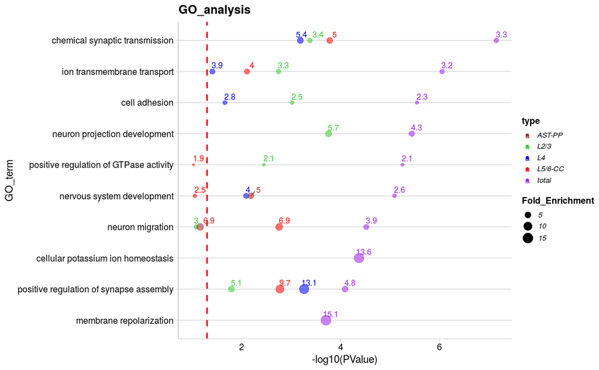

```r
library(tidyverse)
library(ggplot2)
library(ggrepel)
library(cowplot)


term = readxl::read_xlsx("DAVID_TOTAL.xlsx") %>% .[1:10,] %>% select("Term2", "Fold Enrichment", "FDR") %>% mutate(type = 'total', Fold_Enrichment = round(`Fold Enrichment`, 1)) %>% select(Term2)

ggplot(rbind.data.frame(readxl::read_xlsx("DAVID_L4.xlsx") %>%
                          select("Term2", "Fold Enrichment", "FDR", "PValue") %>%
                          filter(Term2 %in% term$Term2) %>%
                          mutate(type = 'L4',
                                 Fold_Enrichment = round(`Fold Enrichment`, 1)),
                        readxl::read_xlsx("DAVID_L23.xlsx") %>%
                          select("Term2", "Fold Enrichment", "FDR", "PValue") %>%
                          filter(Term2 %in% term$Term2) %>%
                          mutate(type = 'L2/3',
                                 Fold_Enrichment = round(`Fold Enrichment`, 1)),
                        readxl::read_xlsx("DAVID_ASTPP.xlsx") %>%
                          select("Term2", "Fold Enrichment", "FDR", "PValue") %>%
                          filter(Term2 %in% term$Term2) %>%
                          mutate(type = 'AST-PP',
                                 Fold_Enrichment = round(`Fold Enrichment`, 1)),
                        readxl::read_xlsx("DAVID_L56CC.xlsx") %>%
                          select("Term2", "Fold Enrichment", "FDR", "PValue") %>%
                          filter(Term2 %in% term$Term2) %>%
                          mutate(type = 'L5/6-CC',
                                 Fold_Enrichment = round(`Fold Enrichment`, 1)),
                        readxl::read_xlsx("DAVID_TOTAL.xlsx") %>%
                          .[1:10,] %>%
                          select("Term2", "Fold Enrichment", "FDR", "PValue") %>%
                          mutate(type = 'total',
                                 Fold_Enrichment = round(`Fold Enrichment`,1))),
       aes(x = -log10(PValue),y = Term2, color = type, label = Fold_Enrichment)) +
  geom_point(aes(size = Fold_Enrichment, alpha = 0.5)) +
  geom_text_repel(nudge_x = 0.1, nudge_y = 0.2) +
  guides(alpha = FALSE) +
  theme_minimal_hgrid() +
  scale_color_manual(values = c("brown", "limegreen", "blue", "red","purple")) +
  labs(y = "GO_term") +
  scale_y_discrete(limits=rev(term$Term2)) +
  labs(title = "GO_analysis") +
  geom_vline(xintercept = -log10(0.05), linetype='dashed', color='red', size=1) +
  theme(plot.title = element_text(lineheight=.8, face="bold"),
        legend.title = element_text(size = 12, face = "bold"),
        legend.text = element_text(size = 10, face = "italic"),
        axis.line.y.left = element_line(size = 0.1))
```

그 결과 위와 같은 그래프가 그려졌습니다. 각 GO term들은 대부분 Neuron의 발달과 기능 등에 관련된 term으로 ASD에 유의미한 term이라고 판단하였습니다. 또한 total GO term 모두 p-value < 0.05, Fold Enrichment > 2를 만족하였습니다. 그리고 L2/3, L4, L5/6-CC 모두 5개 이상의 GO term을 가지고 있으며 대부분이 p-value < 0.05, Fold Enrichment > 2를 만족하였습니다. 그러나 AST-PP는 GO term이 2개 match 되었으며 그중 하나는 pvalue가 0.05 이상이었습니다.

즉, neuronal cell types most enriched for DEGs in several ASD patients인 L2/3, L4, L5/6-CC의 대부분의 GO term들의 Fold Enrichment는 2배가 넘고 p-value 또한 0.05 미만임을 확인하였기 때문에 해당 cell type의 DEG들이 ASD 환자에서 질병의 발생에 유의미한 gene들이라고 판단하였습니다.

반면, non-neuronal cell types most enriched for DEGs in several ASD patients인 AST-PP의 GO term은 2개만 일치하며 그 중 조건을 만족하는 것은 1개뿐이기 해당 cell type의 DEG들이 ASD 환자에서 질병의 발생에 유의미한 gene들이 아니라고 판단하였습니다.

결과적으로 cell type 중 전체 DEG 대비 특이적으로 여러 ASD 환자들에서 공통적으로 DEG를 보이는 neuronal cell들이 ASD 발생에 유의미한 DEG를 가진다는 결론을 내릴 수 있었습니다.